# Is your sleep optimum?

## https://aroo738.github.io/stats220/visual_data_story.html

[figure not shown]

Alarm Clock

An analysis of sleep data using the health app on Samsung phones to obtain the numbers of hours of sleep obtained per day +between the 10th to the 30th of March and additionally the past 5 days between the 9th and 13th of May. The collection of data and analysis was conducted on both me and my friend Bill’s sleep data.

## An overview

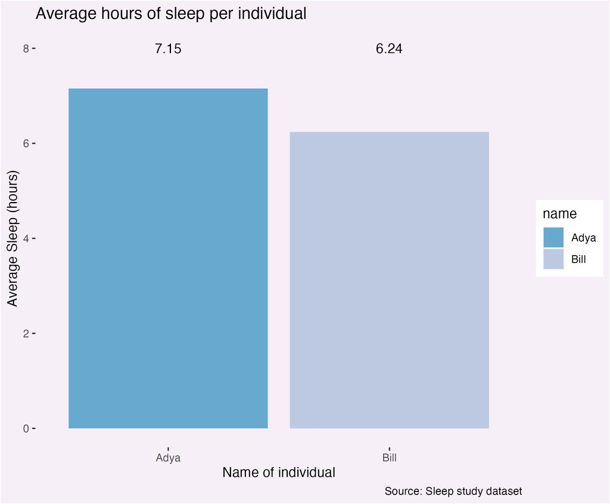

Average hours of sleep obtained per individual

Average hours of sleep per individual bar chart, generated by summarising total sleep data conducted gives us an overview of the sleep obtained by both individuals. Indicating that I obtained on average more sleep than Bill.

## Well rested?

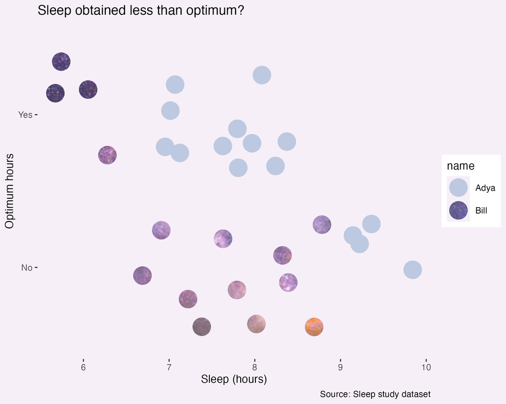

Comparison if sleep obtained was less than the optimum number of hours per individual

The scatter plot visualises if sleep obtained was less than the optimum number of hours for each individual. Produced by geom_point() in R, with galaxy overlay using cuttingshapes and magick packages.

We used the optimum variable which varied for each individual depending on how many hours they believe they require to to feel well rested typically. For me my optimum number of hours of sleep I believe I require on average is 9 hours and is 7 hours for Bill.

## Sleeping better now?

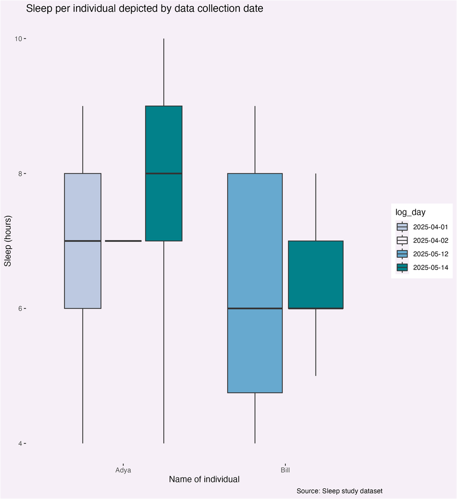

Sleep per individual depicted by data collection date

The data collected in the past 5 days (between the 9th and 13th of May), is indicated in the dark green colour and is the most recent time stamp as it was most recently recorded. The blue shades indicate respective sleep data between the 10th and 30th of march which was collected previously. The line in my side of the plot indicates the addition of a single observation on a seperate day in April whilst testing out live dynamic reporting.